# Final Project_Group 1

#### 2. Collinearity

Checking for collinearity between hard.drugs and hard.times

We wanted to check for collinearity between hard.drugs and hard.times because we felt they captured a similar effect on income. Usage of hard drugs can be considered experiencing a hard time, and could mean collinearity between the two.

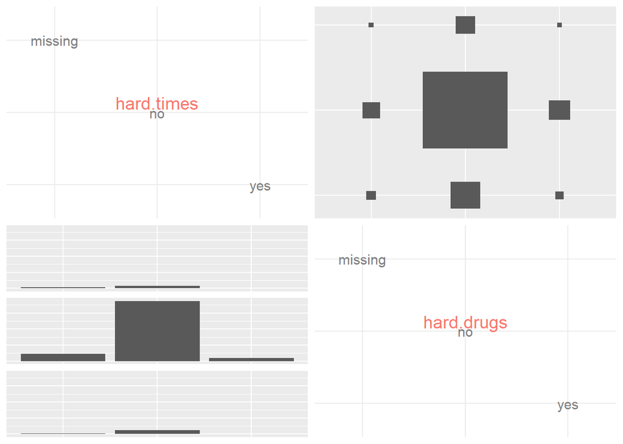

The pairs plot for hard.drugs and hard.times shows a cause for concern. The pair: *hard.drugs = no, hard.times = no* has a considerably larger box in the top-right plot. This box represents the group size of people who said no to both categories. Therefore, suggesting that either one would capture the effect of the other variable without having to include the other variable in the regression. This shows collinearity between hard.drugs and hard.times, allowing us to drop one of the two.

```
##
## Call:
## lm(formula = income ~ sex + hard.times + hard.drugs, data = renamed_nlsy)
##
## Residuals:
##    Min     1Q Median     3Q    Max
## -52010 -20017  -4967  14983 104983
##
## Coefficients:
##               Estimate Std. Error t value Pr(>|t|)
## (Intercept)    47099.8     2131.2  22.100  < 2e-16 ***
## sexFemale     -11994.9      795.8 -15.073  < 2e-16 ***
## hard.timesno     959.2     1271.9   0.754   0.4508
## hard.timesyes  -8851.0     2201.5  -4.020  5.9e-05 ***
## hard.drugsno    3952.6     1899.7   2.081   0.0375 *
## hard.drugsyes   1902.8     2463.8   0.772   0.4400
## ---
## Signif. codes:  0 '***' 0.001 '**' 0.01 '*' 0.05 '.' 0.1 ' ' 1
##
## Residual standard error: 27930 on 4927 degrees of freedom
## Multiple R-squared:  0.05005,    Adjusted R-squared:  0.04909
## F-statistic: 51.92 on 5 and 4927 DF,  p-value: < 2.2e-16
```

```
## Analysis of Variance Table
##
## Model 1: income ~ sex + hard.times
## Model 2: income ~ sex + hard.times + hard.drugs
##   Res.Df        RSS Df  Sum of Sq      F  Pr(>F)
## 1   4929 3.8490e+12
## 2   4927 3.8447e+12  2 4329116365 2.7739 0.06252 .
## ---
## Signif. codes:  0 '***' 0.001 '**' 0.01 '*' 0.05 '.' 0.1 ' ' 1
```

```
## Analysis of Variance Table
##
## Model 1: income ~ sex + hard.drugs
## Model 2: income ~ sex + hard.times + hard.drugs
##   Res.Df        RSS Df  Sum of Sq      F  Pr(>F)
## 1   4929 3.8656e+12
## 2   4927 3.8447e+12  2 2.0884e+10 13.382 1.6e-06 ***
## ---
## Signif. codes:  0 '***' 0.001 '**' 0.01 '*' 0.05 '.' 0.1 ' ' 1
```

```
##
## Call:
## lm(formula = income ~ sex + hard.times, data = renamed_nlsy)
##
## Residuals:
##    Min     1Q Median     3Q    Max
## -51733 -19740  -4740  14265 105260
##
## Coefficients:
##               Estimate Std. Error t value Pr(>|t|)
## (Intercept)      50548       1261  40.072  < 2e-16 ***
## sexFemale       -11994        796 -15.068  < 2e-16 ***
## hard.timesno      1187       1268   0.936    0.349
## hard.timesyes    -8706       2201  -3.955 7.77e-05 ***
## ---
## Signif. codes:  0 '***' 0.001 '**' 0.01 '*' 0.05 '.' 0.1 ' ' 1
##
## Residual standard error: 27940 on 4929 degrees of freedom
## Multiple R-squared:  0.04898,    Adjusted R-squared:  0.0484
## F-statistic: 84.62 on 3 and 4929 DF,  p-value: < 2.2e-16
```

The decision to drop either of the two: hard.drugs and hard.times depended on anova test to check the statistical significance of the remaining variable when one was dropped from the linear regression model. hard.times came out to be more statistically significant, therefore, hard.drugs was dropped.

#### 3. Interaction Term

```
##
## Call:
## lm(formula = income ~ sex, data = renamed_nlsy)
##
## Residuals:
##    Min     1Q Median     3Q    Max
## -51135 -20137  -4659  13863 105841
##
## Coefficients:
##             Estimate Std. Error t value Pr(>|t|)
## (Intercept)  51136.7      559.2   91.44   <2e-16 ***
## sexFemale   -11977.6      797.9  -15.01   <2e-16 ***
## ---
## Signif. codes:  0 '***' 0.001 '**' 0.01 '*' 0.05 '.' 0.1 ' ' 1
##
## Residual standard error: 28020 on 4931 degrees of freedom
## Multiple R-squared:  0.0437, Adjusted R-squared:  0.04351
## F-statistic: 225.3 on 1 and 4931 DF,  p-value: < 2.2e-16
```

```
##
## Call:
## lm(formula = income ~ sex + race, data = renamed_nlsy)
##
## Residuals:
##    Min     1Q Median     3Q    Max
## -55177 -19327  -4233  14673 108767
##
## Coefficients:
##                               Estimate Std. Error t value Pr(>|t|)
## (Intercept)                    42641.5      891.1  47.852  < 2e-16 ***
## sexFemale                     -11408.1      784.9 -14.535  < 2e-16 ***
## raceHispanic                    6480.3     1160.8   5.583  2.5e-08 ***
## raceMixed Race (Non-Hispanic)  11993.9     4090.4   2.932  0.00338 **
## raceNon-Black / Non-Hispanic   12685.7      953.1  13.310  < 2e-16 ***
## ---
## Signif. codes:  0 '***' 0.001 '**' 0.01 '*' 0.05 '.' 0.1 ' ' 1
##
## Residual standard error: 27520 on 4928 degrees of freedom
## Multiple R-squared:  0.07796,    Adjusted R-squared:  0.07721
## F-statistic: 104.2 on 4 and 4928 DF,  p-value: < 2.2e-16
```

```
## Analysis of Variance Table
##
## Model 1: income ~ sex
## Model 2: income ~ sex + race
##   Res.Df        RSS Df  Sum of Sq      F    Pr(>F)
## 1   4931 3.8704e+12
## 2   4928 3.7318e+12  3 1.3863e+11 61.025 < 2.2e-16 ***
## ---
## Signif. codes:  0 '***' 0.001 '**' 0.01 '*' 0.05 '.' 0.1 ' ' 1
```

```
##
## Call:
## lm(formula = income ~ sex + race + sex * race, data = renamed_nlsy)
##
## Residuals:
##    Min     1Q Median     3Q    Max
## -56052 -19202  -4458  13798 106018
##
## Coefficients:
##                                         Estimate Std. Error t value Pr(>|t|)
## (Intercept)                                39458       1152  34.259  < 2e-16
## sexFemale                                  -5475       1572  -3.483 0.000501
## raceHispanic                               10719       1659   6.460 1.15e-10
## raceMixed Race (Non-Hispanic)              16782       5614   2.989 0.002810
## raceNon-Black / Non-Hispanic               16744       1368  12.242  < 2e-16
## sexFemale:raceHispanic                     -8085       2320  -3.485 0.000496
## sexFemale:raceMixed Race (Non-Hispanic)    -9361       8184  -1.144 0.252759
## sexFemale:raceNon-Black / Non-Hispanic     -7791       1905  -4.090 4.38e-05
##
## (Intercept)                             ***
## sexFemale                               ***
## raceHispanic                            ***
## raceMixed Race (Non-Hispanic)           **
## raceNon-Black / Non-Hispanic            ***
## sexFemale:raceHispanic                  ***
## sexFemale:raceMixed Race (Non-Hispanic)
## sexFemale:raceNon-Black / Non-Hispanic  ***
## ---
## Signif. codes:  0 '***' 0.001 '**' 0.01 '*' 0.05 '.' 0.1 ' ' 1
##
## Residual standard error: 27470 on 4925 degrees of freedom
## Multiple R-squared:  0.0815, Adjusted R-squared:  0.08019
## F-statistic: 62.43 on 7 and 4925 DF,  p-value: < 2.2e-16
```

```
## Analysis of Variance Table
##
## Model 1: income ~ sex + race
## Model 2: income ~ sex + race + sex * race
##   Res.Df        RSS Df  Sum of Sq      F   Pr(>F)
## 1   4928 3.7318e+12
## 2   4925 3.7174e+12  3 1.4341e+10 6.3332 0.000278 ***
## ---
## Signif. codes:  0 '***' 0.001 '**' 0.01 '*' 0.05 '.' 0.1 ' ' 1
```

```
##
## Call:
## lm(formula = income ~ sex + marital.status, data = renamed_nlsy)
##
## Residuals:
##    Min     1Q Median     3Q    Max
## -56702 -19491  -4914  14555 107624
##
## Coefficients:
##                             Estimate Std. Error t value Pr(>|t|)
## (Intercept)                    47478       1300  36.513  < 2e-16 ***
## sexFemale                     -11988        784 -15.290  < 2e-16 ***
## marital.statusMarried           9423       1346   7.003 2.84e-12 ***
## marital.statusmissing          -4827       5162  -0.935    0.350
## marital.statusNever married    -2034       1377  -1.477    0.140
## marital.statusSeparated        -3115       2957  -1.053    0.292
## marital.statusWidowed          -5900       6774  -0.871    0.384
## ---
## Signif. codes:  0 '***' 0.001 '**' 0.01 '*' 0.05 '.' 0.1 ' ' 1
##
## Residual standard error: 27460 on 4926 degrees of freedom
## Multiple R-squared:  0.08219,    Adjusted R-squared:  0.08108
## F-statistic: 73.52 on 6 and 4926 DF,  p-value: < 2.2e-16
```

```
## Analysis of Variance Table
##
## Model 1: income ~ sex
## Model 2: income ~ sex + marital.status
##   Res.Df        RSS Df  Sum of Sq      F    Pr(>F)
## 1   4931 3.8704e+12
## 2   4926 3.7146e+12  5 1.5579e+11 41.318 < 2.2e-16 ***
## ---
## Signif. codes:  0 '***' 0.001 '**' 0.01 '*' 0.05 '.' 0.1 ' ' 1
```

```
##
## Call:
## lm(formula = income ~ sex + marital.status + sex * marital.status,
##     data = renamed_nlsy)
##
## Residuals:
##    Min     1Q Median     3Q    Max
## -59503 -19310  -4643  13836 106397
##
## Coefficients:
##                                       Estimate Std. Error t value Pr(>|t|)
## (Intercept)                              46581       1854  25.130  < 2e-16 ***
## sexFemale                               -10417       2453  -4.247 2.21e-05 ***
## marital.statusMarried                    13122       2012   6.522 7.62e-11 ***
## marital.statusmissing                    -2804       6698  -0.419   0.6755
## marital.statusNever married              -3978       2045  -1.945   0.0518 .
## marital.statusSeparated                 -10490       4152  -2.526   0.0116 *
## marital.statusWidowed                     9752      15874   0.614   0.5390
## sexFemale:marital.statusMarried          -7299       2696  -2.708   0.0068 **
## sexFemale:marital.statusmissing          -4386      10468  -0.419   0.6753
## sexFemale:marital.statusNever married     4456       2757   1.617   0.1060
## sexFemale:marital.statusSeparated        15636       5894   2.653   0.0080 **
## sexFemale:marital.statusWidowed         -19488      17544  -1.111   0.2667
## ---
## Signif. codes:  0 '***' 0.001 '**' 0.01 '*' 0.05 '.' 0.1 ' ' 1
##
## Residual standard error: 27310 on 4921 degrees of freedom
## Multiple R-squared:  0.09344,    Adjusted R-squared:  0.09141
## F-statistic: 46.11 on 11 and 4921 DF,  p-value: < 2.2e-16
```

```
## Analysis of Variance Table
##
## Model 1: income ~ sex + marital.status
## Model 2: income ~ sex + marital.status + sex * marital.status
##   Res.Df        RSS Df  Sum of Sq      F    Pr(>F)
## 1   4926 3.7146e+12
## 2   4921 3.6691e+12  5 4.5514e+10 12.209 8.765e-12 ***
## ---
## Signif. codes:  0 '***' 0.001 '**' 0.01 '*' 0.05 '.' 0.1 ' ' 1
```

```
## Analysis of Variance Table
##
## Model 1: income ~ sex
## Model 2: income ~ sex + hard.drugs
##   Res.Df        RSS Df Sum of Sq      F Pr(>F)
## 1   4931 3.8704e+12
## 2   4929 3.8656e+12  2 4.819e+09 3.0724 0.0464 *
## ---
## Signif. codes:  0 '***' 0.001 '**' 0.01 '*' 0.05 '.' 0.1 ' ' 1
```

```
##
## Call:
## lm(formula = income ~ sex + hard.drugs + sex * hard.drugs, data = renamed_nlsy)
##
## Residuals:
##    Min     1Q Median     3Q    Max
## -51466 -19468  -4465  14532 105535
##
## Coefficients:
##                         Estimate Std. Error t value Pr(>|t|)
## (Intercept)                45744       2567  17.817   <2e-16 ***
## sexFemale                  -8869       3704  -2.394   0.0167 *
## hard.drugsno                5724       2634   2.173   0.0299 *
## hard.drugsyes               4678       3470   1.348   0.1776
## sexFemale:hard.drugsno     -3134       3799  -0.825   0.4095
## sexFemale:hard.drugsyes    -5106       4936  -1.034   0.3010
## ---
## Signif. codes:  0 '***' 0.001 '**' 0.01 '*' 0.05 '.' 0.1 ' ' 1
##
## Residual standard error: 28010 on 4927 degrees of freedom
## Multiple R-squared:  0.0451, Adjusted R-squared:  0.04413
## F-statistic: 46.54 on 5 and 4927 DF,  p-value: < 2.2e-16
```

```
## Analysis of Variance Table
##
## Model 1: income ~ sex + hard.drugs
## Model 2: income ~ sex + hard.drugs + sex * hard.drugs
##   Res.Df        RSS Df Sum of Sq    F Pr(>F)
## 1   4929 3.8656e+12
## 2   4927 3.8647e+12  2 847072797 0.54 0.5828
```

```
##  [1] "total.incarcerations"  "marijuana"             "sex"
##  [4] "marital.status"        "high.school.diploma"   "parenthood.by.20"
##  [7] "chance.college.degree" "hard.times"            "work.limitation"
## [10] "citizenship"           "mother.edu"            "father.edu"
## [13] "race"                  "hard.drugs"            "public.private"
## [16] "highest.degree"        "emp_industry_2011"     "job.type"
## [19] "income"
```

```
## Analysis of Variance Table
##
## Model 1: income ~ sex
## Model 2: income ~ sex + hard.times
##   Res.Df        RSS Df  Sum of Sq      F    Pr(>F)
## 1   4931 3.8704e+12
## 2   4929 3.8490e+12  2 2.1374e+10 13.686 1.183e-06 ***
## ---
## Signif. codes:  0 '***' 0.001 '**' 0.01 '*' 0.05 '.' 0.1 ' ' 1
```

```
##
## Call:
## lm(formula = income ~ sex + hard.times + sex * hard.times, data = renamed_nlsy)
##
## Residuals:
##    Min     1Q Median     3Q    Max
## -51883 -19583  -4583  14475 105417
##
## Coefficients:
##                         Estimate Std. Error t value Pr(>|t|)
## (Intercept)              50524.6     1719.8  29.378  < 2e-16 ***
## sexFemale               -11949.9     2384.9  -5.011 5.62e-07 ***
## hard.timesno              1360.2     1823.5   0.746 0.455753
## hard.timesyes           -11294.0     3076.5  -3.671 0.000244 ***
## sexFemale:hard.timesno    -352.2     2537.7  -0.139 0.889636
## sexFemale:hard.timesyes   5467.6     4407.4   1.241 0.214828
## ---
## Signif. codes:  0 '***' 0.001 '**' 0.01 '*' 0.05 '.' 0.1 ' ' 1
##
## Residual standard error: 27940 on 4927 degrees of freedom
## Multiple R-squared:  0.04943,    Adjusted R-squared:  0.04847
## F-statistic: 51.25 on 5 and 4927 DF,  p-value: < 2.2e-16
```

```
## Analysis of Variance Table
##
## Model 1: income ~ sex + hard.times
## Model 2: income ~ sex + hard.times + sex * hard.times
##   Res.Df        RSS Df  Sum of Sq     F Pr(>F)
## 1   4929 3.8490e+12
## 2   4927 3.8472e+12  2 1825592360 1.169 0.3108
```

```
##  [1] "total.incarcerations"  "marijuana"             "sex"
##  [4] "marital.status"        "high.school.diploma"   "parenthood.by.20"
##  [7] "chance.college.degree" "hard.times"            "work.limitation"
## [10] "citizenship"           "mother.edu"            "father.edu"
## [13] "race"                  "hard.drugs"            "public.private"
## [16] "highest.degree"        "emp_industry_2011"     "job.type"
## [19] "income"
```

```
## Analysis of Variance Table
##
## Model 1: income ~ sex
## Model 2: income ~ sex + highest.degree
##   Res.Df        RSS Df  Sum of Sq      F    Pr(>F)
## 1   4931 3.8704e+12
## 2   4923 3.1779e+12  8 6.9246e+11 134.09 < 2.2e-16 ***
## ---
## Signif. codes:  0 '***' 0.001 '**' 0.01 '*' 0.05 '.' 0.1 ' ' 1
```